# HERV and IFN Gene Expression in Microglia: Correlation with Braak Stage

Raquel Garza

## Overview

This notebook analyzes the expression of **upregulated HERVs** and **IFN-related genes** in microglia. The objectives are:

1. To **compare expression profiles** of IFN-related genes and HERVs across brain regions.
2. To **associate expression levels** of selected genes and HERVs with **Braak stage** using linear fits with p-values and R² values.

## Load libraries and input data

```r
library(openxlsx)
library(ggplot2)
library(tidyverse)
library(data.table)
library(stringr)
library(ggpmisc)
samplesheet <- read.xlsx("/Volumes/MyPassport/ASAP/code/ASAP_PMDBS_snRNAseq/original/ASAP_samplesheet.xlsx")
genes <- read.xlsx("/Volumes/MyPassport/ASAP/data/ASAP_PMDBS_snRNAseq/results/tables/IFN_related_genes_GO_microglia.xlsx")
hervs <- read.xlsx("/Volumes/MyPassport/ASAP/data/ASAP_PMDBS_snRNAseq/results/tables/all_HERVs_microglia.xlsx")

genes$type <- "IFN_gene"
hervs$type <- "HERV"
colnames(genes)[6] <- "id"
colnames(hervs)[6] <- "id"
```

## IFN-related gene expression & HERV expression

Combine and visualize IFN gene vs HERV expression across regions. Boxplot and jitter showing log2FC for genes and HERVs in different regions

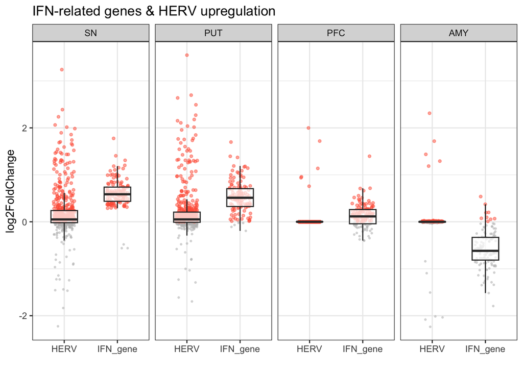

```r
genes_hervs <- rbind(hervs[,c("log2FoldChange","pvalue", "id", "region", "type")],
                     genes[,c("log2FoldChange","pvalue", "id", "region", "type")])

genes_hervs$region <- factor(genes_hervs$region, levels = c("SN", "PUT", "PFC", "AMY"))

ggplot(genes_hervs, aes(x=type, y=log2FoldChange)) + geom_jitter(aes(color=ifelse(log2FoldChange > 0, T, F), size=ifelse(log2FoldChange > 0, T, F)),height = 0, width = 0.2, alpha=0.5) + geom_boxplot(outliers = F, width=0.5, alpha=0.7) + facet_wrap(.~region, ncol=4) + theme_bw() + labs(x="") + ggtitle("IFN-related genes & HERV upregulation") + scale_color_manual(values=c("TRUE" = "tomato", "FALSE"= "grey")) + theme(legend.position = "None") + scale_size_manual(values=c("TRUE" = 1, "FALSE"= 0.5))
```

## Filter Substantia Nigra (SN) pseudobulks by nuclei count

Load nuclei counts per cluster for SN and remove small pseudobulks

```r
SN_num_nuclei <- read.table("/Volumes/MyPassport/ASAP/code/ASAP_PMDBS_snRNAseq/original/number_nuclei/SN_clusters.txt", header = F, skip = 1)
colnames(SN_num_nuclei) <- c("cluster", "num_nuclei")
num_nuclei <- SN_num_nuclei
# There is a "total" row. I'll remove that for convenience
num_nuclei <- num_nuclei[which(num_nuclei$cluster != "total"),]
rownames(num_nuclei) <- num_nuclei$cluster

num_nuclei <- num_nuclei[which(num_nuclei$num_nuclei > 50),] # Remove tiny pseudobulks
```

## Compare IFN Gene expression to donor’s Braak stage

- Load normalized gene counts from script `gene_DEA_GSEA.Rmd`
- Normalize and reshape gene expression data
- Merge with metadata
- Filter significant upregulated IFN genes in SN
- Subset data to PD samples with known Braak stage

```r
load("/Volumes/MyPassport/ASAP/code/ASAP_PMDBS_snRNAseq/original/src/r_scripts/gene_uniq_DEA.Rdata")
samplesheet <- read.xlsx("/Volumes/MyPassport/ASAP/code/ASAP_PMDBS_snRNAseq/original/ASAP_samplesheet.xlsx")
gene_counts_norm_microglia_SN <- as.data.frame(gene_counts_norm$`4`$SN[genes$gene_id,])
gene_counts_norm_microglia_SN$gene_id <- rownames(gene_counts_norm_microglia_SN)
gene_counts_norm_microglia_SN_melt <- reshape2::melt(gene_counts_norm_microglia_SN)
gene_counts_norm_microglia_SN_melt$sample <- str_sub(gene_counts_norm_microglia_SN_melt$variable, end = -3)
gene_counts_norm_microglia_SN_melt <- merge(gene_counts_norm_microglia_SN_melt, samplesheet, by.x= "sample", by.y="Sample")
genes_split_region <- split(genes, f = genes$region)

# Filter significant upregulated IFN genes in SN
upreg_IFN_genes_SN <- genes_split_region$SN[which(genes_split_region$SN$log2FoldChange > 0 & genes_split_region$SN$pvalue < 0.05), "gene_id"]

gene_counts_norm_microglia_SN_melt_tmp <- gene_counts_norm_microglia_SN_melt %>%
  filter(Dx == "PD") %>%
  filter(Braak != "pending") %>% # Subset data to PD samples with known Braak stage
  filter(gene_id %in% upreg_IFN_genes_SN)

gene_counts_norm_microglia_SN_melt_tmp$Braak <- as.numeric(gene_counts_norm_microglia_SN_melt_tmp$Braak)
```

## Visualization of selected IFN Genes vs Braak Stage (All Upregulated)

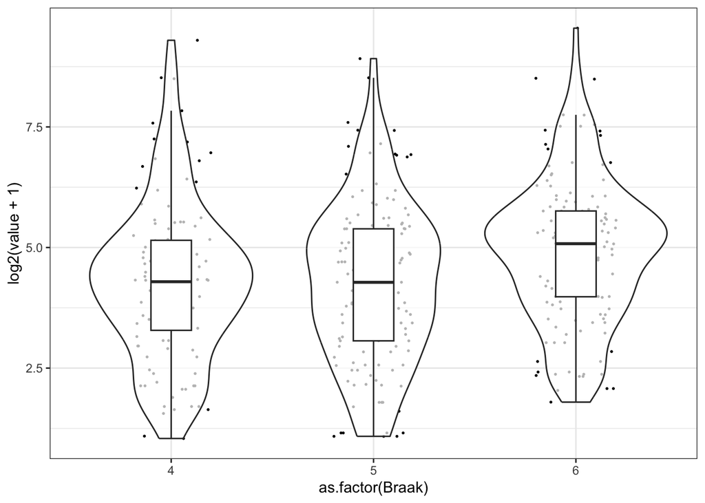

```r
gene_counts_norm_microglia_SN_melt_tmp %>%
  filter(gene_counts_norm_microglia_SN_melt_tmp$variable %in% num_nuclei$cluster) %>%
ggplot(aes(x=as.factor(Braak), y=log2(value+1))) + geom_jitter(width = 0.2, size=0.3) +
 geom_violin(alpha=0.7) + geom_boxplot(width= 0.2, outliers = F) + theme_bw()
```

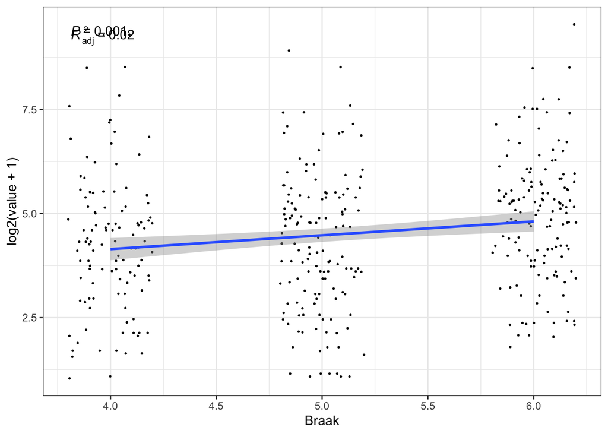

```r
gene_counts_norm_microglia_SN_melt_tmp %>%
  filter(gene_counts_norm_microglia_SN_melt_tmp$variable %in% num_nuclei$cluster) %>%
ggplot(aes(x=Braak, y=log2(value+1))) + geom_jitter(width = 0.2, size=0.3) +
 stat_poly_line(formula = y ~ x) +
  stat_poly_eq(formula = y ~ x, aes(label = after_stat(p.value.label))) +
  stat_poly_eq(formula = y ~ x, aes(label = after_stat(adj.rr.label))) + theme_bw()
```

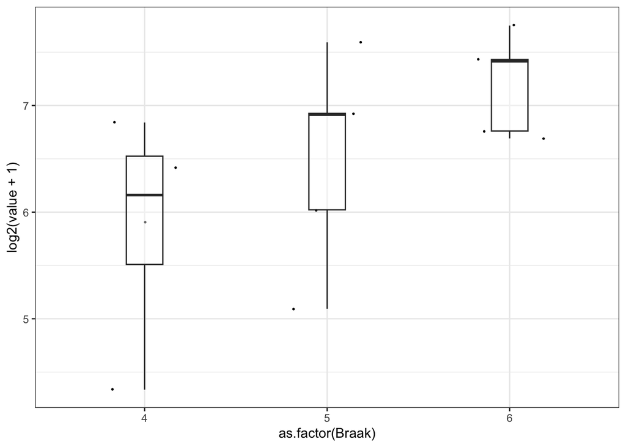

```r
gene_counts_norm_microglia_SN_melt_tmp %>%
  filter(gene_counts_norm_microglia_SN_melt_tmp$variable %in% num_nuclei$cluster) %>%
  filter(gene_id == "CIITA") %>%
ggplot(aes(x=as.factor(Braak), y=log2(value+1))) + geom_jitter(width = 0.2, size=0.3) +
 geom_boxplot(width= 0.2, alpha=0.4, outliers = F) + theme_bw()
```

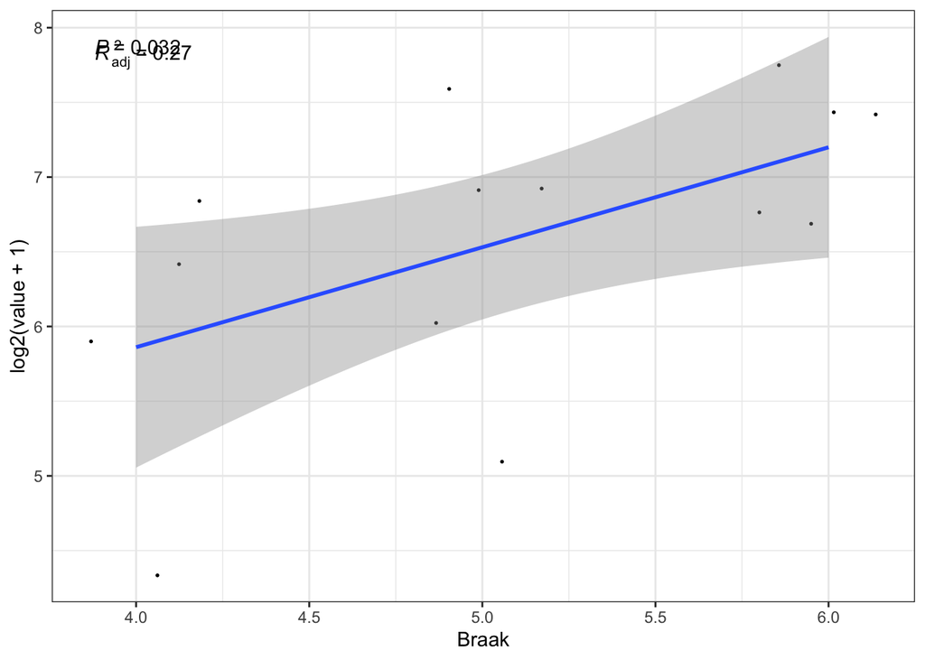

```r
gene_counts_norm_microglia_SN_melt_tmp %>%
  filter(gene_counts_norm_microglia_SN_melt_tmp$variable %in% num_nuclei$cluster) %>%
  filter(gene_id == "CIITA") %>%
ggplot(aes(x=Braak, y=log2(value+1))) + geom_jitter(width = 0.2, size=0.3) +
 stat_poly_line(formula = y ~ x) +
  stat_poly_eq(formula = y ~ x, aes(label = after_stat(p.value.label))) +
  stat_poly_eq(formula = y ~ x, aes(label = after_stat(adj.rr.label))) + theme_bw()
```

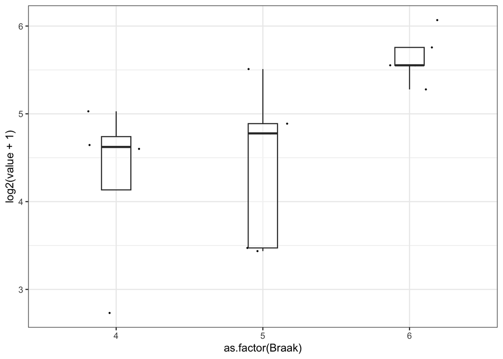

```r
gene_counts_norm_microglia_SN_melt_tmp %>%
  filter(gene_counts_norm_microglia_SN_melt_tmp$variable %in% num_nuclei$cluster) %>%
  filter(gene_id == "TLR4") %>%
ggplot(aes(x=as.factor(Braak), y=log2(value+1))) + geom_jitter(width = 0.2, size=0.3) +
 geom_boxplot(width= 0.2, alpha=0.4, outliers = F) + theme_bw()
```

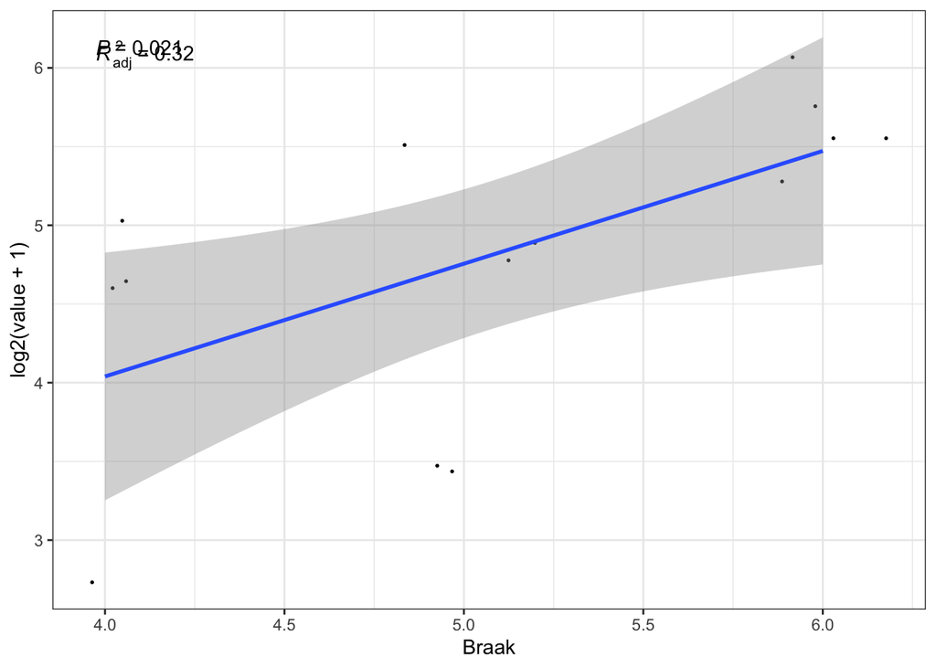

```r
gene_counts_norm_microglia_SN_melt_tmp %>%
  filter(gene_counts_norm_microglia_SN_melt_tmp$variable %in% num_nuclei$cluster) %>%
  filter(gene_id == "TLR4") %>%
ggplot(aes(x=Braak, y=log2(value+1))) + geom_jitter(width = 0.2, size=0.3) +
 stat_poly_line(formula = y ~ x) +
  stat_poly_eq(formula = y ~ x, aes(label = after_stat(p.value.label))) +
  stat_poly_eq(formula = y ~ x, aes(label = after_stat(adj.rr.label))) + theme_bw()
```

## Compare HERV expression to donor’s Braak stage

- Load list of upregulated HERVs in SN microglia
- Load normalized HERV counts from script `HERV_expression_PDvsCtl.Rmd`
- Normalize and reshape HERV expression data
- Merge with metadata
- Subset data to PD samples with known Braak stage

```r
res_hervs_SN_microglia <- read.xlsx("/Volumes/MyPassport/ASAP/data/ASAP_PMDBS_snRNAseq/results/tables/all_HERVs_microglia.xlsx")
upreg_hervs_SN_microglia <- res_hervs_SN_microglia %>%
  filter(region == "SN" & padj < 0.05 & log2FoldChange > 1)
herv_counts_norm <- readRDS("/Volumes/MyPassport/ASAP/code/ASAP_PMDBS_snRNAseq/processing/HERV_norm_expression.rds")

hervs_counts_norm_microglia_SN <- as.data.frame(herv_counts_norm$SN_4[upreg_hervs_SN_microglia$HERV_id,])
hervs_counts_norm_microglia_SN$hervs_id <- rownames(hervs_counts_norm_microglia_SN)
hervs_counts_norm_microglia_SN_melt <- reshape2::melt(hervs_counts_norm_microglia_SN)
```

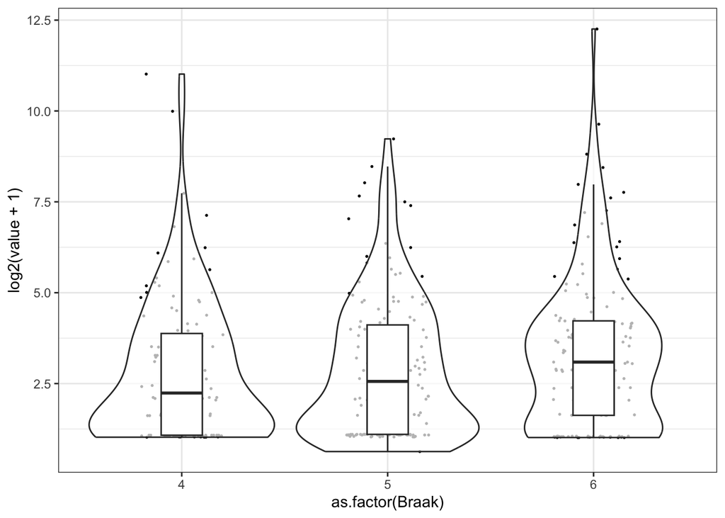

```r
hervs_counts_norm_microglia_SN_melt$variable <- as.character(hervs_counts_norm_microglia_SN_melt$variable)
hervs_counts_norm_microglia_SN_melt$sample <- str_sub(hervs_counts_norm_microglia_SN_melt$variable, end = -3)

hervs_counts_norm_microglia_SN_melt <- merge(hervs_counts_norm_microglia_SN_melt, samplesheet, by.x= "sample", by.y="Sample")

hervs_split_region <- split(hervs, f = hervs$region)
upreg_hervs_SN <- hervs_split_region$SN[which(hervs_split_region$SN$log2FoldChange > 0 & hervs_split_region$SN$pvalue < 0.05), "id"]

hervs_counts_norm_microglia_SN_melt_tmp <- hervs_counts_norm_microglia_SN_melt %>%
  filter(Dx == "PD") %>%
  filter(Braak != "pending") %>%
  filter(hervs_id %in% upreg_hervs_SN)

hervs_counts_norm_microglia_SN_melt_tmp$Braak <- as.numeric(hervs_counts_norm_microglia_SN_melt_tmp$Braak)

hervs_counts_norm_microglia_SN_melt_tmp %>%
  filter(hervs_counts_norm_microglia_SN_melt_tmp$variable %in% num_nuclei$cluster) %>%
ggplot(aes(x=as.factor(Braak), y=log2(value+1))) + geom_jitter(width = 0.2, size=0.3) +
 geom_violin(alpha=0.7) + geom_boxplot(width= 0.2, outliers = F) + theme_bw()
```

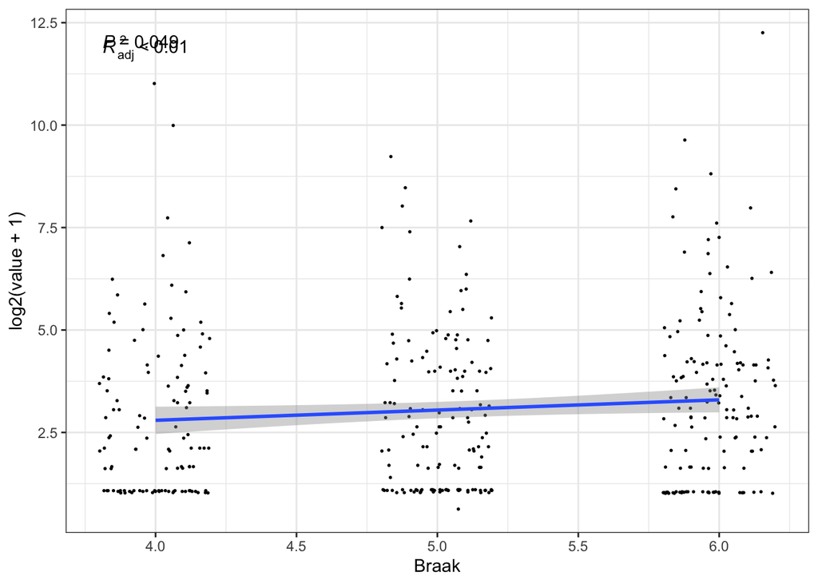

```r
hervs_counts_norm_microglia_SN_melt_tmp %>%
  filter(hervs_counts_norm_microglia_SN_melt_tmp$variable %in% num_nuclei$cluster) %>%
ggplot(aes(x=Braak, y=log2(value+1))) + geom_jitter(width = 0.2, size=0.3) +
 stat_poly_line(formula = y ~ x) +
  stat_poly_eq(formula = y ~ x, aes(label = after_stat(p.value.label))) +
  stat_poly_eq(formula = y ~ x, aes(label = after_stat(adj.rr.label))) + theme_bw()
```

## Visualization of selected HERVs vs Braak Stage

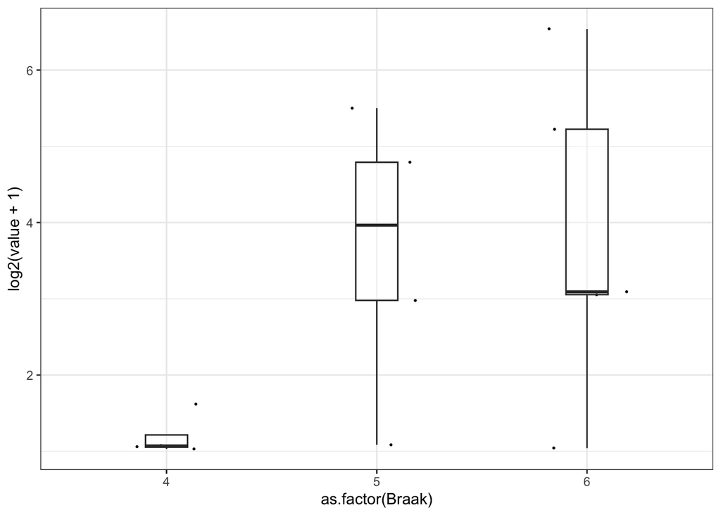

```r
hervs_counts_norm_microglia_SN_melt_tmp %>%
  filter(hervs_counts_norm_microglia_SN_melt_tmp$variable %in% num_nuclei$cluster) %>%
  filter(hervs_id == "HERV_dup2643") %>%
ggplot(aes(x=as.factor(Braak), y=log2(value+1))) + geom_jitter(width = 0.2, size=0.3) +
 geom_boxplot(width= 0.2, alpha=0.4, outliers = F) + theme_bw()
```

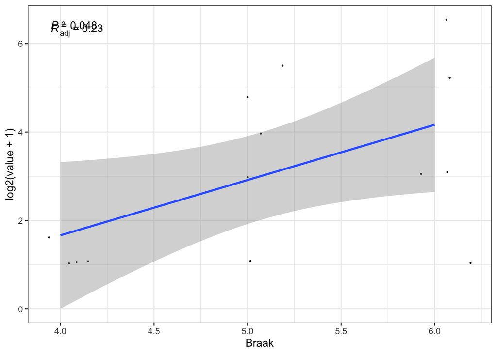

```r
hervs_counts_norm_microglia_SN_melt_tmp %>%
  filter(hervs_counts_norm_microglia_SN_melt_tmp$variable %in% num_nuclei$cluster) %>%
  filter(hervs_id == "HERV_dup2643") %>%
ggplot(aes(x=Braak, y=log2(value+1))) + geom_jitter(width = 0.2, size=0.3) +
 stat_poly_line(formula = y ~ x) +
  stat_poly_eq(formula = y ~ x, aes(label = after_stat(p.value.label))) +
  stat_poly_eq(formula = y ~ x, aes(label = after_stat(adj.rr.label))) + theme_bw()
```

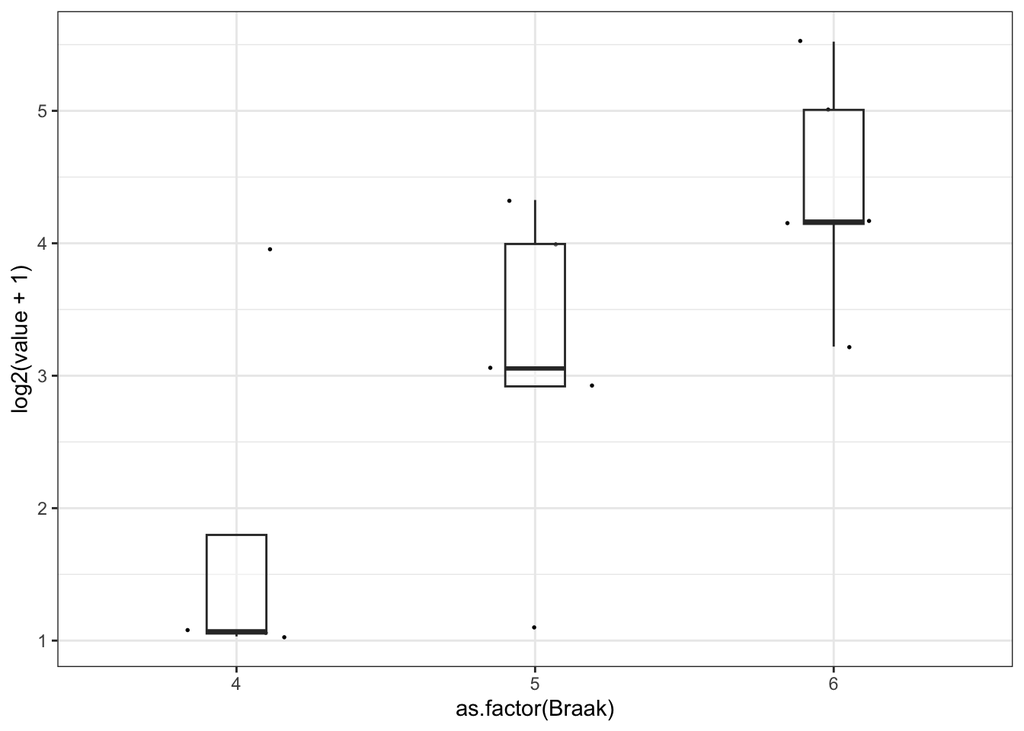

```r
hervs_counts_norm_microglia_SN_melt_tmp %>%
  filter(hervs_counts_norm_microglia_SN_melt_tmp$variable %in% num_nuclei$cluster) %>%
  filter(hervs_id == "HERV_dup2623") %>%
ggplot(aes(x=as.factor(Braak), y=log2(value+1))) + geom_jitter(width = 0.2, size=0.3) +
 geom_boxplot(width= 0.2, alpha=0.4, outliers = F) + theme_bw()
```

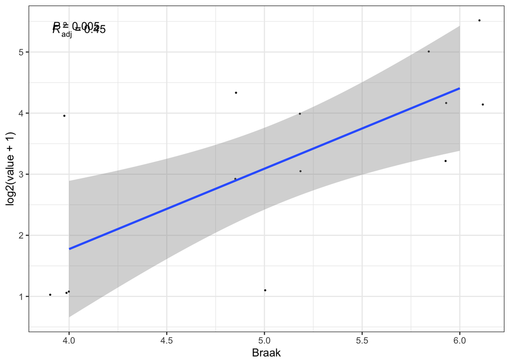

```r
hervs_counts_norm_microglia_SN_melt_tmp %>%
  filter(hervs_counts_norm_microglia_SN_melt_tmp$variable %in% num_nuclei$cluster) %>%
  filter(hervs_id == "HERV_dup2623") %>%
ggplot(aes(x=Braak, y=log2(value+1))) + geom_jitter(width = 0.2, size=0.3) +
 stat_poly_line(formula = y ~ x) +
  stat_poly_eq(formula = y ~ x, aes(label = after_stat(p.value.label))) +
  stat_poly_eq(formula = y ~ x, aes(label = after_stat(adj.rr.label))) + theme_bw()
```

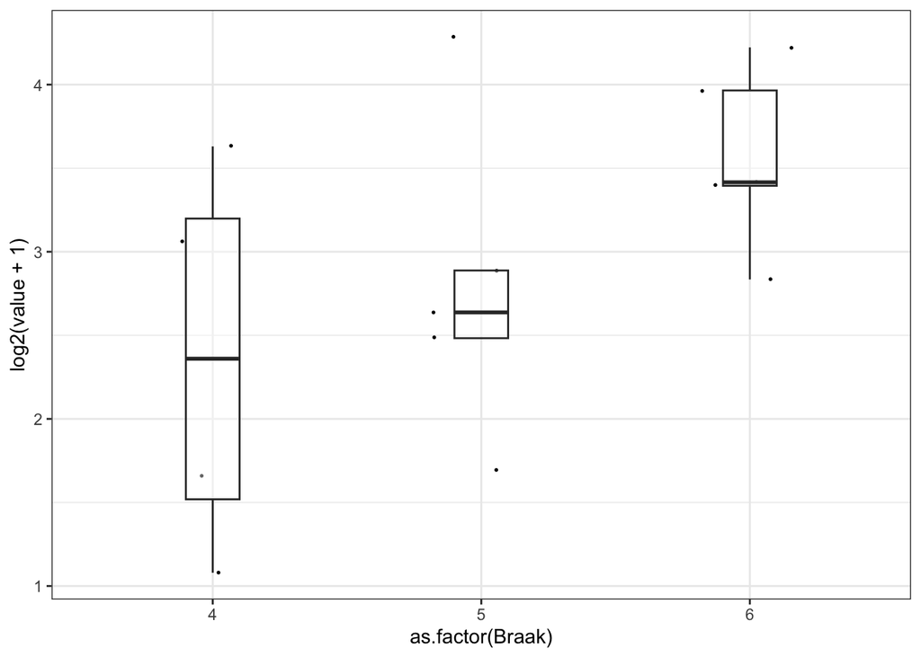

```r
hervs_counts_norm_microglia_SN_melt_tmp %>%
  filter(hervs_counts_norm_microglia_SN_melt_tmp$variable %in% num_nuclei$cluster) %>%
  filter(hervs_id == "HERV_dup2412") %>%
ggplot(aes(x=as.factor(Braak), y=log2(value+1))) + geom_jitter(width = 0.2, size=0.3) +
 geom_boxplot(width= 0.2, alpha=0.4, outliers = F) + theme_bw()
```

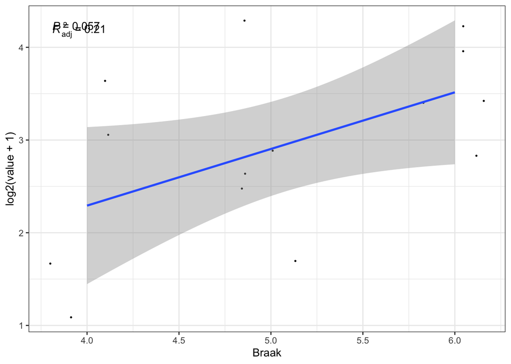

```r
hervs_counts_norm_microglia_SN_melt_tmp %>%
  filter(hervs_counts_norm_microglia_SN_melt_tmp$variable %in% num_nuclei$cluster) %>%
  filter(hervs_id == "HERV_dup2412") %>%
ggplot(aes(x=Braak, y=log2(value+1))) + geom_jitter(width = 0.2, size=0.3) +
 stat_poly_line(formula = y ~ x) +
  stat_poly_eq(formula = y ~ x, aes(label = after_stat(p.value.label))) +
  stat_poly_eq(formula = y ~ x, aes(label = after_stat(adj.rr.label))) + theme_bw()
```